# Cluster Analysis

Catherine Pargeter

July 27, 2014

Example Cluster analysis for use in separating data by multiple columns based on natural break in the data.

## Example Data

Data for this example: df.c holds 4 columns; the Level, rock type, the L.tech (technical length), and W.mid(width at the mid point).

```r
  df.c<-data.frame(Level = rep(c("A","B","C"),each = 30),
  Rock = rep(c("Rock1","Rock2","Rock3","Rock4","Rock5"),18),
  L.tech = rnorm(90,mean=5), W.mid = rnorm(90))
```

## Required Libraries

- fpc
- ggplot2

[output not shown]

## Question

Is there a break in the data sets that would separate the data by technical length and width at mid point. Show the data in terms of Rock type and/or Level Note: Some code based off work from StackOverFlow - http://stackoverflow.com/questions/15376075/cluster-analysis-in-r-determine-the-optimal-number-of-clusters

## Methodology

Determine the number of clusters - plots the Sum of Square Erros Scree Plot for 1 to 20 clusters. Change the maximum number of cluster depending on your data, or if the original plot is not showing sufficient convergence towards minimal SSE

Note, in this example, the clusters are based on columns 3 and 4

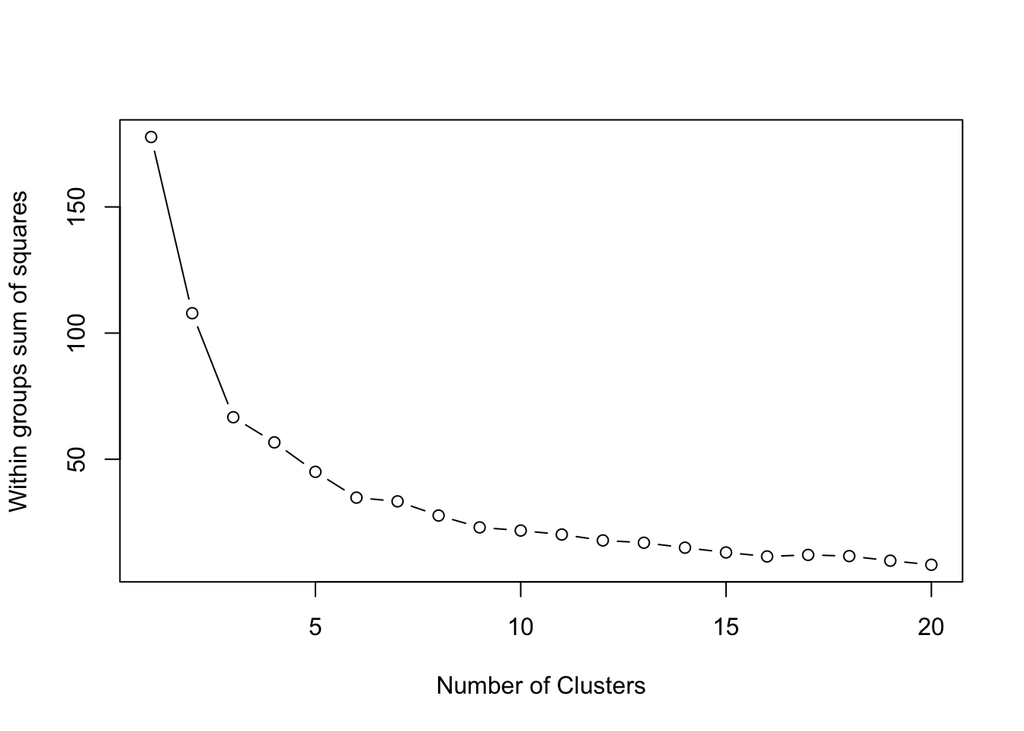

```r
wss <- (nrow(df.c[,3:4])-1)*sum(apply(df.c[,3:4],2,var))
    for (i in 2:20) wss[i] <- sum(kmeans(df.c[,3:4],centers=i)$withinss)
    plot(1:20, wss, type="b", xlab="Number of Clusters", ylab="Within groups sum of squares")
```

Partion around medoids to estimate the best number of clusters

```r
    pamk.best <- pamk(df.c[,3:4])
    cat("Optimimum number of clusters:", pamk.best$nc, "\n")
```

```
## Optimimum number of clusters: 3
```

Plot Clusters - you can either use the number that Partioning returned (pamk.best$nc) or enter the amount based on your visual inspection of the SSE plot. The plot below shows the data separated by Level, using shape = Level, and gives the color based on the assigned cluster.

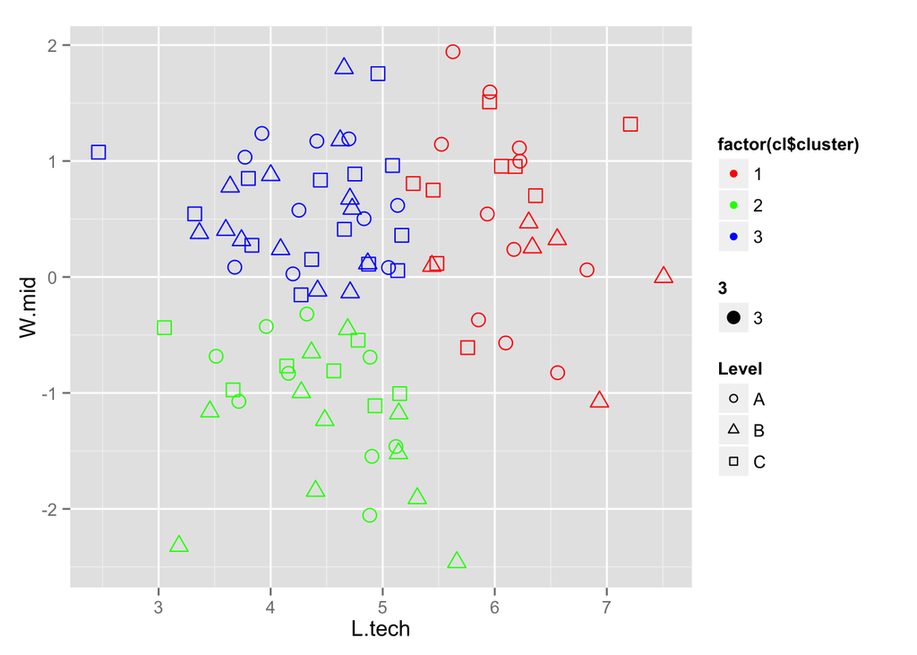

```r
  n <- pamk.best$nc
  cl <- kmeans(df.c[,c(3:4)], n)
    p<- ggplot(data = df.c,aes(x = L.tech, y= W.mid))
    p1<- p+ geom_point(aes(shape = Level, col= factor(cl$cluster), size=3)) +
        scale_shape(solid = FALSE) +
        scale_colour_manual(values = rainbow(n))
    p1
```